# Análise de correlação canônica

Matheus Nunes Paiva

2024-05-19

# 1 Introdução

A Análise de Correlação Canônica (ACC) é uma técnica estatística multivariada sofisticada que tem como objetivo principal descobrir e quantificar a associação entre dois conjuntos de variáveis. Através da criação de combinações lineares, também conhecidas como variáveis canônicas, a ACC maximiza a correlação entre os conjuntos de variáveis. Esta técnica é empregada em uma variedade de campos, incluindo economia, ecologia e psicologia, para analisar a interação entre variáveis multidimensionais e auxiliar na tomada de decisões baseadas em dados. A ACC, portanto, atua como uma ferramenta para explorar a estrutura de correlação entre dois conjuntos de variáveis, fornecendo uma compreensão mais profunda da natureza dessas relações.

# 2 Carregando pacotes

```r
library(tidyverse)
library(readxl)
library(DT)
library(ggcorrplot)
library(corrplot)
library(CCA)
library(CCP)
library(candisc)
```

# 3 Conjunto de dados

Os dados utilizados são do pacote palmerpenguins, que contém informações sobre pinguins. O conjunto de dados contém 344 observações e 8 variáveis. As variáveis que serão utilizadas são: bill_length_mm: comprimento do bico em milímetros. bill_depth_mm: profundidade do bico em milímetros. flipper_length_mm: comprimento da nadadeira em milímetros. body_mass_g: massa corporal em gramas.

Essas variáveis serão divididas em dois conjuntos de dados, X e Y, para a análise de correlação canônica.

```r
data("penguins", package = 'palmerpenguins')
Dados<- penguins
Dados <- na.omit(Dados)
Dados<- Dados[,c(3:6)]
datatable(Dados,
           class = "row-border hover",
      options = list(
        scrollX = TRUE,
        dom = 'ltipr'
      ))
```

|  | bill_length_mm | bill_depth_mm | flipper_length_mm | body_mass_g |
| --- | --- | --- | --- | --- |
| 1 | 39.1 | 18.7 | 181 | 3750 |
| 2 | 39.5 | 17.4 | 186 | 3800 |
| 3 | 40.3 | 18 | 195 | 3250 |
| 4 | 36.7 | 19.3 | 193 | 3450 |
| 5 | 39.3 | 20.6 | 190 | 3650 |
| 6 | 38.9 | 17.8 | 181 | 3625 |
| 7 | 39.2 | 19.6 | 195 | 4675 |
| 8 | 41.1 | 17.6 | 182 | 3200 |
| 9 | 38.6 | 21.2 | 191 | 3800 |
| 10 | 34.6 | 21.1 | 198 | 4400 |

[output cut: 323 more lines]

# 4 Gráfico da matriz de correlação

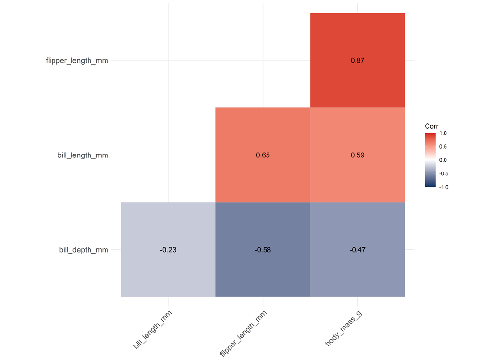

```r
X<- Dados[,1:2]
Y<- Dados[,3:4]
XY<- cbind(X,Y)
 ggcorrplot(
            cor(XY),
            hc.order = T,
            type = "lower",
            lab = T,
            colors = c("#003262", "#FFFFFF", "#D21E1C")
          )
```

# 5 Análise de correlação canônica

```r
CCA<-cancor(X,Y, set.names = c("X", "Y"))
CCA
```

```
##
## Canonical correlation analysis of:
##   2   X  variables:  bill_length_mm, bill_depth_mm
##   with    2   Y  variables:  flipper_length_mm, body_mass_g
##
##      CanR   CanRSQ    Eigen percent    cum                          scree
## 1 0.78763 0.620363 1.634098  99.542  99.54 ******************************
## 2 0.08639 0.007463 0.007519   0.458 100.00
##
## Test of H0: The canonical correlations in the
## current row and all that follow are zero
##
##    CanR LR test stat approx F numDF denDF Pr(> F)
## 1 0.788        0.377    103.5     4   658  <2e-16 ***
## 2 0.086        0.993      2.5     1   330    0.12
## ---
## Signif. codes:  0 '***' 0.001 '**' 0.01 '*' 0.05 '.' 0.1 ' ' 1
```

A saída anterior apresenta a correlação do par de variáveis canônicas e o teste de hipótese para a significância da correlação canônica. No nosso exemplo, apenas um par de variável canônica foi significativo, utilizando um alpha de 0.05. A correlação do par de variável canônica foi de 0.788 e a porcentagem da variância explicada foi de aproximadamente 99%.

# 6 Coeficientes canônicos

```r
coef(CCA, type = "both", standardize = T)
```

```
## [[1]]
##                  Xcan1  Xcan2
## bill_length_mm -0.6969 0.7546
## bill_depth_mm   0.5753 0.8510
##
## [[2]]
##                     Ycan1  Ycan2
## flipper_length_mm -1.0240 -1.776
## body_mass_g        0.0276  2.050
```

# 7 Gráficos para a verificação da qualidade do ajuste

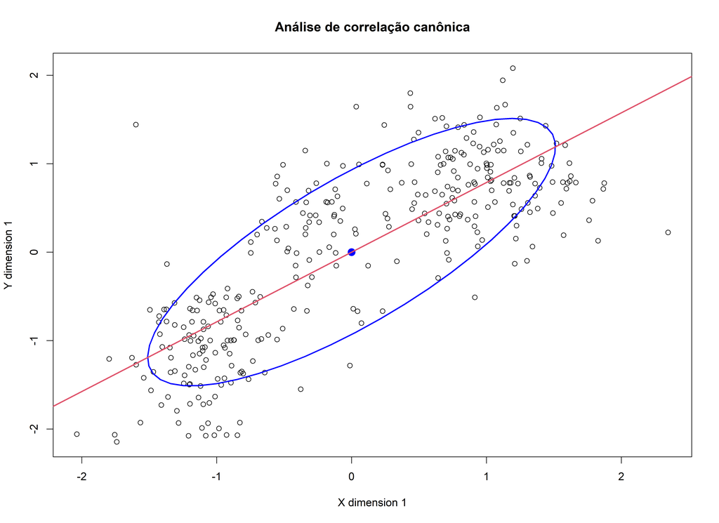

```r
plot(CCA,  main = "Análise de correlação canônica")
```

Este gráfico é o gráfico de dispersão dos escores canônicos. Ele mostra a relação entre os escores canônicos de X e Y. Se os escores canônicos de X e Y estiverem correlacionados, os pontos estarão alinhados em uma linha. Se os escores canônicos de X e Y não estiverem correlacionados, os pontos estarão dispersos. Por padrão a função traça uma elipse que capta 68% dos dados, quanto mais achatada estiver essa elipse, maior a correlação entre os escores canônicos.

Perceba que este gráfico foi feito apenas para o par de variáveis canônicas significativo, caso houvesse mais de um par significativo, deverá ser feito um gráfico para cada par.

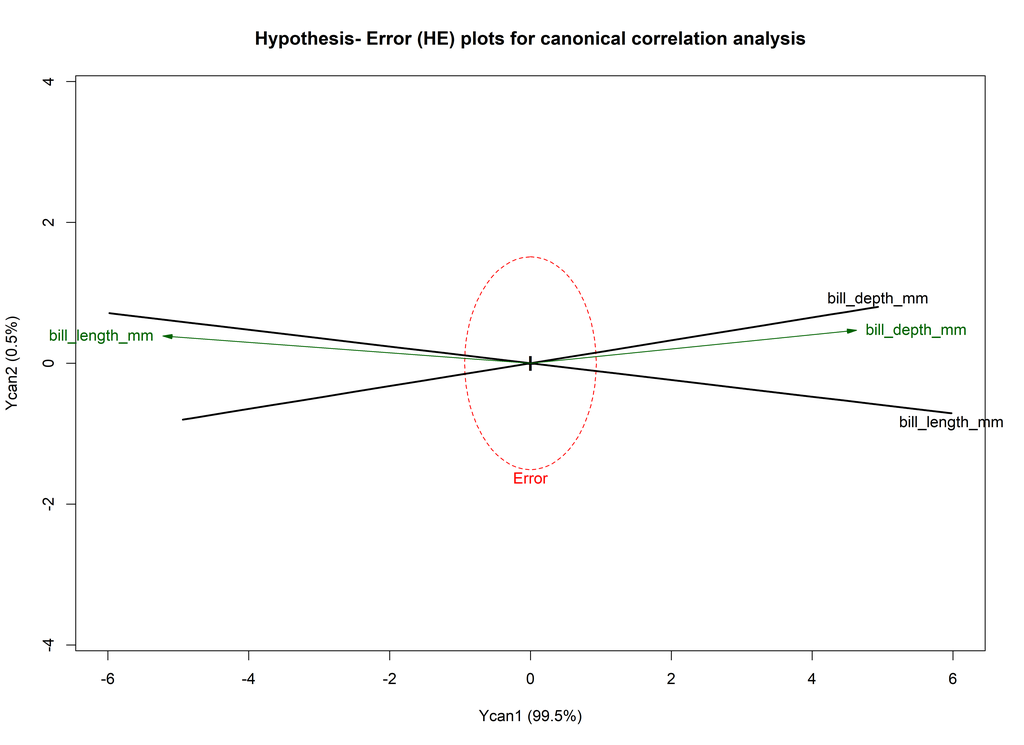

```
## Vector scale factor set to  8
```

```r
heplot(CCA, col=c("red", "black"),var.vectors = "X" ,main = "Hypothesis- Error (HE) plots for canonical correlation analysis")
```

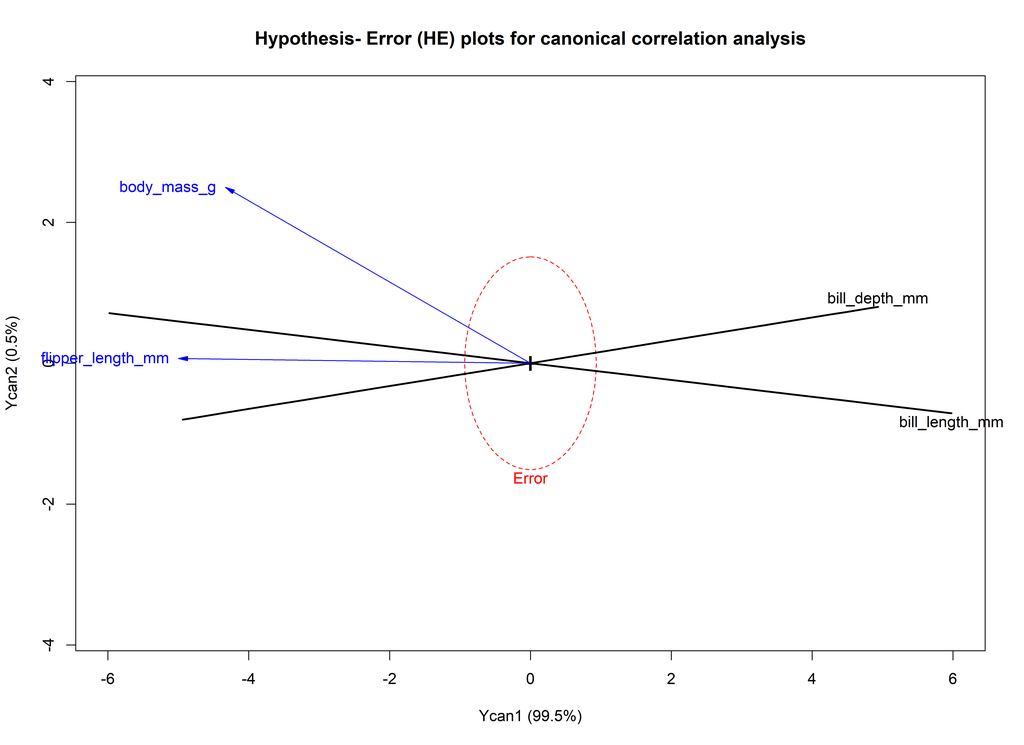

```
## Vector scale factor set to  5
```

```r
heplot(CCA, col=c("red", "black"),var.vectors = "Y" ,main = "Hypothesis- Error (HE) plots for canonical correlation analysis")
```

Os 2 gráficos anteriores são os gráficos de hipótese-erro (HE). Eles mostram a relação entre os escores canônicos e as variáveis originais. Se as variáveis originais estiverem correlacionadas com os escores canônicos, elas estarão alinhadas com os vetores canônicos. Quanto maior o tamanho da reta, mais significativa é a variável original para a variável canônica.

A elipse no centro do gráfico é a elipse para os erros, quanto menor a elipse, melhor o ajuste do modelo.